# Feature Selection

```python
import numpy as np
import pandas as pd
import matplotlib.pyplot as plt
import seaborn as sns
```

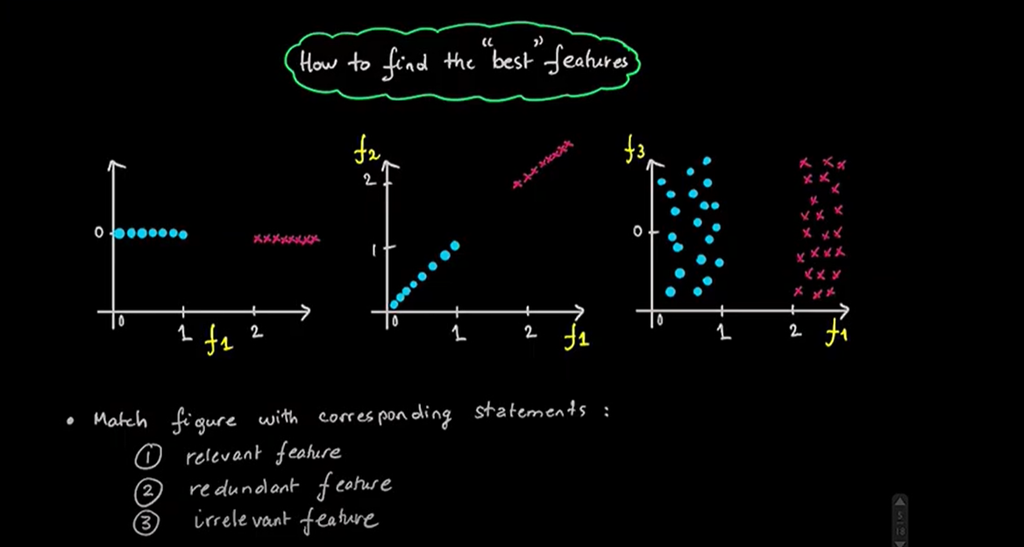

#### The efficiency of all the Machine learning algorithm lies in feature selection and this is as important as data cleaning to improve the efficiency of our algorithm. Let's see this one by one

### The main idea lies in below

#### 1) for Classification - feature selection depends on correlation

#### 2) for Regression - feature selection depends Score

### Before getting into wrapper and filter methods of feature selection , let's see 3 feature selection that are easy to use

#### 1. Univariate Selection

#### 2. Feature Importance

#### 3.Correlation Matrix with Heatmap

## 1. Univariate Selection

#### for this we use the mobile range dataset from kaggle

```python
mobile = pd.read_csv(r'D:\learning\Python\MachineLearning\featureSelection\mobile.csv')
```

```python
mobile.head()
```

|  | battery_power | blue | clock_speed | dual_sim | fc | four_g | int_memory | m_dep | mobile_wt | n_cores | ... | px_height | px_width | ram | sc_h | sc_w | talk_time | three_g | touch_screen | wifi | price_range |
| --- | --- | --- | --- | --- | --- | --- | --- | --- | --- | --- | --- | --- | --- | --- | --- | --- | --- | --- | --- | --- | --- |
| 0 | 842 | 0 | 2.2 | 0 | 1 | 0 | 7 | 0.6 | 188 | 2 | ... | 20 | 756 | 2549 | 9 | 7 | 19 | 0 | 0 | 1 | 1 |
| 1 | 1021 | 1 | 0.5 | 1 | 0 | 1 | 53 | 0.7 | 136 | 3 | ... | 905 | 1988 | 2631 | 17 | 3 | 7 | 1 | 1 | 0 | 2 |
| 2 | 563 | 1 | 0.5 | 1 | 2 | 1 | 41 | 0.9 | 145 | 5 | ... | 1263 | 1716 | 2603 | 11 | 2 | 9 | 1 | 1 | 0 | 2 |
| 3 | 615 | 1 | 2.5 | 0 | 0 | 0 | 10 | 0.8 | 131 | 6 | ... | 1216 | 1786 | 2769 | 16 | 8 | 11 | 1 | 0 | 0 | 2 |
| 4 | 1821 | 1 | 1.2 | 0 | 13 | 1 | 44 | 0.6 | 141 | 2 | ... | 1208 | 1212 | 1411 | 8 | 2 | 15 | 1 | 1 | 0 | 1 |

5 rows × 21 columns

```python
mobile.columns
# price_range: This is the target variable with a value of
#0(low cost),
#1(medium cost),
#2(high cost)
#3(very high cost).
```

```
Index(['battery_power', 'blue', 'clock_speed', 'dual_sim', 'fc', 'four_g',
       'int_memory', 'm_dep', 'mobile_wt', 'n_cores', 'pc', 'px_height',
       'px_width', 'ram', 'sc_h', 'sc_w', 'talk_time', 'three_g',
       'touch_screen', 'wifi', 'price_range'],
      dtype='object')
```

```python
mobile.info()
```

```
<class 'pandas.core.frame.DataFrame'>
RangeIndex: 2000 entries, 0 to 1999
Data columns (total 21 columns):
battery_power    2000 non-null int64
blue             2000 non-null int64
clock_speed      2000 non-null float64
dual_sim         2000 non-null int64
fc               2000 non-null int64
four_g           2000 non-null int64
int_memory       2000 non-null int64
m_dep            2000 non-null float64
mobile_wt        2000 non-null int64
n_cores          2000 non-null int64
pc               2000 non-null int64
px_height        2000 non-null int64
px_width         2000 non-null int64
ram              2000 non-null int64
sc_h             2000 non-null int64
sc_w             2000 non-null int64
talk_time        2000 non-null int64
three_g          2000 non-null int64
touch_screen     2000 non-null int64
wifi             2000 non-null int64
price_range      2000 non-null int64
dtypes: float64(2), int64(19)
memory usage: 328.2 KB
```

```python
from sklearn.feature_selection import SelectKBest
# Select features according to the k highest scores.

from sklearn.feature_selection import chi2
#Compute chi-squared stats between each non-negative feature and class.
#This score can be used to select the n_features features with thehighest values for the test chi-squared statistic from X,
#which must contain only non-negative features such as booleans or frequencies
#(e.g., term counts in document classification), relative to the classes.
```

```python
SelectKBest()
```

```
SelectKBest(k=10, score_func=<function f_classif at 0x0000028D91448828>)
```

```python
bestfeatures = SelectKBest(score_func=chi2,k=20)
# k : Number of top features to select.
```

```python
X = mobile.iloc[:,:-1]
y = mobile.iloc[:,-1]
# y = target columns
```

```python
fit = bestfeatures.fit(X,y)
```

```python
bestscores = fit.scores_
columns = X.columns
```

```python
pd.DataFrame({ 'columns' : columns,
               'score' : bestscores }).sort_values(by='score',ascending=False).head(10)
# here you get the 10 best relevant features for determining the price range of your phone
# as you can see the RAM plays a major role in determing the price range
```

|  | columns | score |
| --- | --- | --- |
| 13 | ram | 931267.519053 |
| 11 | px_height | 17363.569536 |
| 0 | battery_power | 14129.866576 |
| 12 | px_width | 9810.586750 |
| 8 | mobile_wt | 95.972863 |
| 6 | int_memory | 89.839124 |
| 15 | sc_w | 16.480319 |
| 16 | talk_time | 13.236400 |
| 4 | fc | 10.135166 |
| 14 | sc_h | 9.614878 |

## 2. Feature Importance

```python
from sklearn.ensemble import ExtraTreesClassifier
#An extra-trees classifier implements a meta estimator that fits a number of randomized decision trees (a.k.a. extra-trees)
#on various sub-samples of the dataset and uses averaging to improve the predictive accuracy and control over-fitting.
```

```python
ExtraTreesClassifier()
```

```
ExtraTreesClassifier(bootstrap=False, class_weight=None, criterion='gini',
                     max_depth=None, max_features='auto', max_leaf_nodes=None,
                     min_impurity_decrease=0.0, min_impurity_split=None,
                     min_samples_leaf=1, min_samples_split=2,
                     min_weight_fraction_leaf=0.0, n_estimators='warn',
                     n_jobs=None, oob_score=False, random_state=None, verbose=0,
                     warm_start=False)
```

```python
model = ExtraTreesClassifier(n_estimators = 200 )
fit  = model.fit(X,y)
```

```python
scores = model.feature_importances_
```

```python
feature_importance = pd.DataFrame({ 'columns' : columns,
                                   'scores' : scores }).sort_values(by='scores',ascending=False).head(10)
feature_importance
```

|  | columns | scores |
| --- | --- | --- |
| 13 | ram | 0.397548 |
| 0 | battery_power | 0.061065 |
| 12 | px_width | 0.049137 |
| 11 | px_height | 0.046566 |
| 8 | mobile_wt | 0.035866 |
| 6 | int_memory | 0.034483 |
| 15 | sc_w | 0.034180 |
| 14 | sc_h | 0.033933 |
| 16 | talk_time | 0.033563 |
| 10 | pc | 0.033489 |

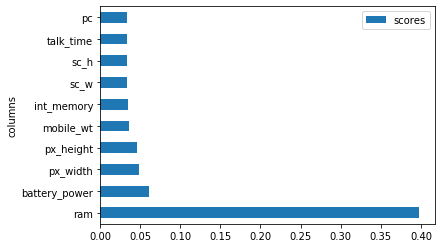

```python
feature_importance.set_index('columns').plot(kind='barh',)
```

## 3.Correlation Matrix with Heatmap

```python
correlation_matrix = mobile.corr()
# Compute pairwise correlation of columns, excluding NA/null values.
```

```python
correlation_matrix.head(5)
```

|  | battery_power | blue | clock_speed | dual_sim | fc | four_g | int_memory | m_dep | mobile_wt | n_cores | ... | px_height | px_width | ram | sc_h | sc_w | talk_time | three_g | touch_screen | wifi | price_range |
| --- | --- | --- | --- | --- | --- | --- | --- | --- | --- | --- | --- | --- | --- | --- | --- | --- | --- | --- | --- | --- | --- |
| battery_power | 1.000000 | 0.011252 | 0.011482 | -0.041847 | 0.033334 | 0.015665 | -0.004004 | 0.034085 | 0.001844 | -0.029727 | ... | 0.014901 | -0.008402 | -0.000653 | -0.029959 | -0.021421 | 0.052510 | 0.011522 | -0.010516 | -0.008343 | 0.200723 |
| blue | 0.011252 | 1.000000 | 0.021419 | 0.035198 | 0.003593 | 0.013443 | 0.041177 | 0.004049 | -0.008605 | 0.036161 | ... | -0.006872 | -0.041533 | 0.026351 | -0.002952 | 0.000613 | 0.013934 | -0.030236 | 0.010061 | -0.021863 | 0.020573 |
| clock_speed | 0.011482 | 0.021419 | 1.000000 | -0.001315 | -0.000434 | -0.043073 | 0.006545 | -0.014364 | 0.012350 | -0.005724 | ... | -0.014523 | -0.009476 | 0.003443 | -0.029078 | -0.007378 | -0.011432 | -0.046433 | 0.019756 | -0.024471 | -0.006606 |
| dual_sim | -0.041847 | 0.035198 | -0.001315 | 1.000000 | -0.029123 | 0.003187 | -0.015679 | -0.022142 | -0.008979 | -0.024658 | ... | -0.020875 | 0.014291 | 0.041072 | -0.011949 | -0.016666 | -0.039404 | -0.014008 | -0.017117 | 0.022740 | 0.017444 |
| fc | 0.033334 | 0.003593 | -0.000434 | -0.029123 | 1.000000 | -0.016560 | -0.029133 | -0.001791 | 0.023618 | -0.013356 | ... | -0.009990 | -0.005176 | 0.015099 | -0.011014 | -0.012373 | -0.006829 | 0.001793 | -0.014828 | 0.020085 | 0.021998 |

5 rows × 21 columns

```python
correlation_matrix.shape
```

```
(21, 21)
```

```
<function matplotlib.pyplot.tight_layout(pad=1.08, h_pad=None, w_pad=None, rect=None)>
```

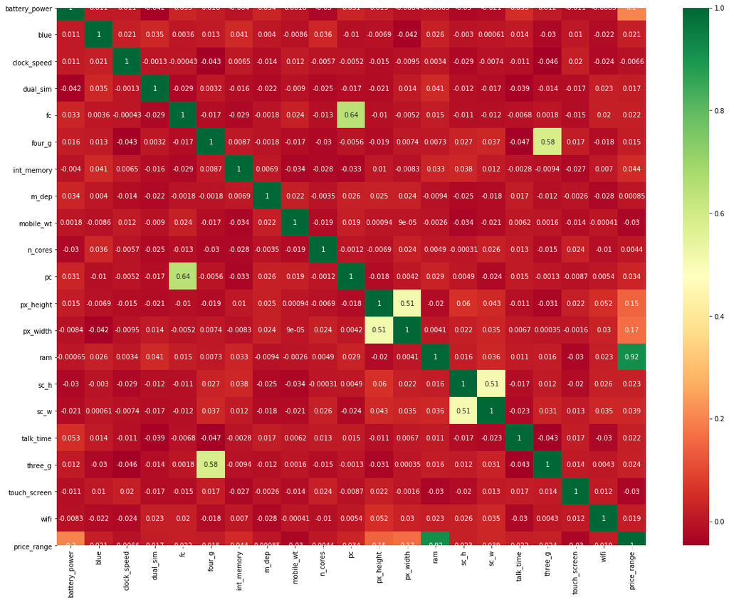

```python
# The magic lies in seaborn
plt.figure(figsize=(20,15))
sns.heatmap(correlation_matrix,cmap='RdYlGn',annot=True)
plt.tight_layout
```

#### Reference : https://towardsdatascience.com/feature-selection-techniques-in-machine-learning-with-python-f24e7da3f36e

#### Let's get into wrapper and filter methods for feature selection

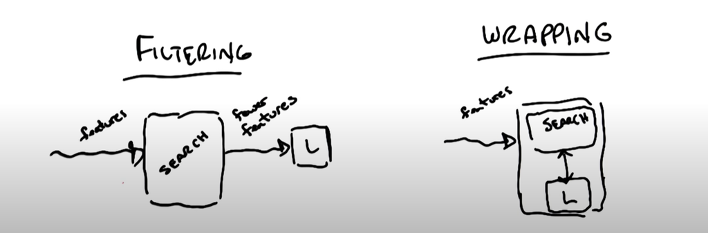

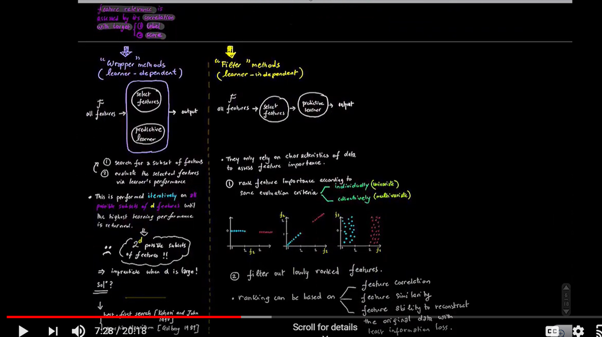

## Wrapper methods

In this method we feed the data to feature selecting algorithm m where the algorithm reads a subset of fatures and returns the k best features to the learning alogorithm , The learning algorithm returns the performance score and communicates to the selection algorithm These two steps repeats until finally it returns you best n features . The computation cost is high as the learning and selection algorithm is interconnected , selection algorithm runs multiple times . This method is suitable for datasets have less columns

### They are classified into 3

#### 1)Step forward feature selection,

#### 2)Step backwards feature selection

#### 3) Exhaustive feature selection.

### Step forward feature selection :

In the first phase of the step forward feature selection, the performance of the classifier is evaluated with respect to each feature. The feature that performs the best is selected out of all the features.

In the second step, the first feature is tried in combination with all the other features. The combination of two features that yield the best algorithm performance is selected. The process continues until the specified number of features are selected.

### Step backwards feature selection

Step backwards feature selection, as the name suggests is the exact opposite of step forward feature selection that we studied in the last section. In the first step of the step backwards feature selection, one feature is removed in round-robin fashion from the feature set and the performance of the classifier is evaluated. The feature set that yields the best performance is retained.

In the second step, again one feature is removed in a round-robin fashion and the performance of all the combination of features except the 2 features is evaluated. This process continues until the specified number of features remain in the dataset.

### Exhaustive feature selection.

In exhaustive feature selection, the performance of a machine learning algorithm is evaluated against all possible combinations of the features in the dataset. The feature subset that yields best performance is selected. The exhaustive search algorithm is the most greedy algorithm of all the wrapper methods since it tries all the combination of features and selects the best.

A downside to exhaustive feature selection is that it can be slower compared to step forward and step backward method since it evaluates all feature combinations.

### Implement and Reference : https://stackabuse.com/applying-wrapper-methods-in-python-for-feature-selection/

## Filter methods

In the filter method the selecting and learning algorithm are independent . The data is fed to selection algorithm and it returns you the best relevant feature scores for each feature , which is then fed to learning algorithm to calculate the performance

This method is very much suitable for large datasets with more features

### They are again classified into 2

#### 1) Univariate Filter Methods

#### 2) Multivariate filter methods.

### Univariate Filter

The univariate filter methods are the type of methods where individual features are ranked according to specific criteria. The top N features are then selected. Different types of ranking criteria are used for univariate filter methods, for example fisher score, mutual information, and variance of the feature.

One of the major disadvantage of univariate filter methods is that they may select redundant features because the relationship between individual features is not taken into account while making decisions. Univariate filter methods are ideal for removing constant and quasi-constant features from the data.

### Multivariate filter

Multivariate filter methods are capable of removing redundant features from the data since they take the mutual relationship between the features into account. Multivariate filter methods can be used to remove duplicate and correlated features from the data.

### Implement and Reference : https://stackabuse.com/applying-filter-methods-in-python-for-feature-selection/